# P21

Klaudia Magda

9 grudnia 2016

# Introduction

In given data set we will make an Extrapolatory Data Analysis.

We will answer following questions:

What are the values in given dataset? What are the distributions? Are there relationships? Where?

What kind of data types?(continuous/discreet/categorical)

Identify outliers Goal of 1st part of project:graphical displays of data and numerical summaries of data

# Libraries

```r
library(xlsx)
library(openxlsx)
library(psych)
library(e1071)
library(caret)
library(magrittr)
library(plyr)
library(dplyr)
library(party)
library(rpart)
```

# Data Preprocessing

First step in data Preprocessing is to drop unnecessary columns that do not have huge impact on our data.

In other columns values NA were replaced with certain value.

```r
describe(dataObserv1)
```

```
##            vars    n    mean      sd  median trimmed     mad min      max
## Kolumna1      1 9999 5000.00 2886.61 5000.00 5000.00 3706.50   1  9999.00
## ID            2 9999 1049.96  798.33  810.00  960.02  738.33 102  3621.00
## lp            3 9999 5100.87 2884.76 5134.00 5115.74 3664.99   1 10077.00
## ekspot*       4 9992     NaN      NA      NA     NaN      NA Inf     -Inf
## kategorie     5 9938    1.97    0.23    2.00    2.00    0.00   1     3.00
## start_min     6 9993   48.17   32.62   44.00   46.32   38.55   0   123.00
## start_s       7 9992   26.95   17.71   27.00   26.80   22.24   0    60.00
## stop_min      8 9994   49.24   32.93   45.00   47.38   38.55   0   125.00
## stop_s        9 9994   27.98   17.68   29.00   27.94   22.24   0   129.00
## czas_w_sek   10 9999   66.05  132.97   34.00   41.72   28.17   0  2830.00
## czas_w_min   11 9999    1.10    2.22    0.57    0.70    0.47   0    47.17
## Z_KIM*       12 6840  945.82  719.10  714.00  894.30  735.37   0  4015.00
## X1_OSTOW*    13 6820 1052.21  805.18  813.00  956.28  736.85   1  3621.00
## X2_OSTOW*    14 3086 1058.11  787.05  905.00  958.75  742.78 102  3619.00
## X3_OSTOW*    15 1246 1080.65  772.60 1103.00  999.09  889.56 102  3617.00
## X4_OSTOW*    16  508 1012.43  641.86 1106.00  953.88  738.33 201  3624.00
## X5_OSTOW     17  138  980.85  511.39 1104.50  951.18  152.71 115  3608.00
## X6_OSTOW     18   59  977.58  324.31 1110.00  993.02   13.34 311  1612.00
## X7_OSTOW     19   21  942.62  387.91 1110.00  973.82  142.33 113  1616.00
## X8_OSTOW     20    4  554.75  250.76  508.50  554.75  158.64 301   901.00
## X9_OSTOW     21    1  912.00      NA  912.00  912.00    0.00 912   912.00
## ILE_OSTOW    22 9999    1.19    1.19    1.00    1.02    1.48   0     9.00
## zach         23 9112    2.43    0.94    3.00    2.42    1.48   1     4.00
## opis         24 1173    1.00    0.00    1.00    1.00    0.00   1     1.00
## animator     25  287    1.00    0.00    1.00    1.00    0.00   1     1.00
## uwagi*       26 1685     NaN      NA      NA     NaN      NA Inf     -Inf
## os_3         27 9999    1.99    0.79    2.00    1.99    1.48   1     3.00
## os_3_e*      28 9999     NaN      NA      NA     NaN      NA Inf     -Inf
## os_2         29 9999    1.68    0.47    2.00    1.73    0.00   1     2.00
## os_2_e*      30 9999     NaN      NA      NA     NaN      NA Inf     -Inf
##               range  skew kurtosis     se
## Kolumna1    9998.00  0.00    -1.20  28.87
## ID          3519.00  1.29     1.90   7.98
## lp         10076.00 -0.03    -1.17  28.85
## ekspot*        -Inf    NA       NA     NA
## kategorie      2.00 -1.86    15.02   0.00
## start_min    123.00  0.37    -0.97   0.33
## start_s       60.00  0.04    -1.21   0.18
## stop_min     125.00  0.38    -0.97   0.33
## stop_s       129.00  0.03    -1.09   0.18
## czas_w_sek  2830.00  8.41   105.01   1.33
## czas_w_min    47.17  8.41   105.00   0.02
## Z_KIM*      4015.00  0.96     1.12   8.69
## X1_OSTOW*   3620.00  1.31     1.92   9.75
## X2_OSTOW*   3517.00  1.41     2.29  14.17
## X3_OSTOW*   3515.00  1.17     1.76  21.89
## X4_OSTOW*   3423.00  1.43     3.91  28.48
## X5_OSTOW    3493.00  1.73     8.04  43.53
## X6_OSTOW    1301.00 -0.62    -0.28  42.22
## X7_OSTOW    1503.00 -0.69    -0.65  84.65
## X8_OSTOW     600.00  0.40    -1.83 125.38
## X9_OSTOW       0.00    NA       NA     NA
## ILE_OSTOW      9.00  1.30     2.30   0.01
## zach           3.00 -0.19    -0.97   0.01
## opis           0.00   NaN      NaN   0.00
## animator       0.00   NaN      NaN   0.00
## uwagi*         -Inf    NA       NA     NA
## os_3           2.00  0.01    -1.41   0.01
## os_3_e*        -Inf    NA       NA     NA
## os_2           1.00 -0.78    -1.39   0.00
## os_2_e*        -Inf    NA       NA     NA
```

```r
dataObs <- subset(dataObserv1, select = -c(Kolumna1, lp, X3_OSTOW, X4_OSTOW, X5_OSTOW, X6_OSTOW, X7_OSTOW, X8_OSTOW, X9_OSTOW, uwagi))

describe(dataObs)
```

```
##            vars    n    mean     sd median trimmed    mad min     max
## ID            1 9999 1049.96 798.33 810.00  960.02 738.33 102 3621.00
## ekspot*       2 9992     NaN     NA     NA     NaN     NA Inf    -Inf
## kategorie     3 9938    1.97   0.23   2.00    2.00   0.00   1    3.00
## start_min     4 9993   48.17  32.62  44.00   46.32  38.55   0  123.00
## start_s       5 9992   26.95  17.71  27.00   26.80  22.24   0   60.00
## stop_min      6 9994   49.24  32.93  45.00   47.38  38.55   0  125.00
## stop_s        7 9994   27.98  17.68  29.00   27.94  22.24   0  129.00
## czas_w_sek    8 9999   66.05 132.97  34.00   41.72  28.17   0 2830.00
## czas_w_min    9 9999    1.10   2.22   0.57    0.70   0.47   0   47.17
## Z_KIM*       10 6840  945.82 719.10 714.00  894.30 735.37   0 4015.00
## X1_OSTOW*    11 6820 1052.21 805.18 813.00  956.28 736.85   1 3621.00
## X2_OSTOW*    12 3086 1058.11 787.05 905.00  958.75 742.78 102 3619.00
## ILE_OSTOW    13 9999    1.19   1.19   1.00    1.02   1.48   0    9.00
## zach         14 9112    2.43   0.94   3.00    2.42   1.48   1    4.00
## opis         15 1173    1.00   0.00   1.00    1.00   0.00   1    1.00
## animator     16  287    1.00   0.00   1.00    1.00   0.00   1    1.00
## os_3         17 9999    1.99   0.79   2.00    1.99   1.48   1    3.00
## os_3_e*      18 9999     NaN     NA     NA     NaN     NA Inf    -Inf
## os_2         19 9999    1.68   0.47   2.00    1.73   0.00   1    2.00
## os_2_e*      20 9999     NaN     NA     NA     NaN     NA Inf    -Inf
##              range  skew kurtosis    se
## ID         3519.00  1.29     1.90  7.98
## ekspot*       -Inf    NA       NA    NA
## kategorie     2.00 -1.86    15.02  0.00
## start_min   123.00  0.37    -0.97  0.33
## start_s      60.00  0.04    -1.21  0.18
## stop_min    125.00  0.38    -0.97  0.33
## stop_s      129.00  0.03    -1.09  0.18
## czas_w_sek 2830.00  8.41   105.01  1.33
## czas_w_min   47.17  8.41   105.00  0.02
## Z_KIM*     4015.00  0.96     1.12  8.69
## X1_OSTOW*  3620.00  1.31     1.92  9.75
## X2_OSTOW*  3517.00  1.41     2.29 14.17
## ILE_OSTOW     9.00  1.30     2.30  0.01
## zach          3.00 -0.19    -0.97  0.01
## opis          0.00   NaN      NaN  0.00
## animator      0.00   NaN      NaN  0.00
## os_3          2.00  0.01    -1.41  0.01
## os_3_e*       -Inf    NA       NA    NA
## os_2          1.00 -0.78    -1.39  0.00
## os_2_e*       -Inf    NA       NA    NA
```

```r
summary(dataObs)
```

```
##        ID          ekspot            kategorie       start_min
##  Min.   : 102   Length:9999        Min.   :1.000   Min.   :  0.00
##  1st Qu.: 412   Class :character   1st Qu.:2.000   1st Qu.: 20.00
##  Median : 810   Mode  :character   Median :2.000   Median : 44.00
##  Mean   :1050                      Mean   :1.973   Mean   : 48.17
##  3rd Qu.:1612                      3rd Qu.:2.000   3rd Qu.: 73.00
##  Max.   :3621                      Max.   :3.000   Max.   :123.00
##                                    NA's   :61      NA's   :6
##     start_s         stop_min          stop_s         czas_w_sek
##  Min.   : 0.00   Min.   :  0.00   Min.   :  0.00   Min.   :   0.00
##  1st Qu.:11.00   1st Qu.: 20.00   1st Qu.: 12.00   1st Qu.:  20.00
##  Median :27.00   Median : 45.00   Median : 29.00   Median :  34.00
##  Mean   :26.95   Mean   : 49.24   Mean   : 27.98   Mean   :  66.05
##  3rd Qu.:42.00   3rd Qu.: 74.00   3rd Qu.: 43.00   3rd Qu.:  64.00
##  Max.   :60.00   Max.   :125.00   Max.   :129.00   Max.   :2830.00
##  NA's   :7       NA's   :5        NA's   :5
##    czas_w_min        Z_KIM             X1_OSTOW           X2_OSTOW
##  Min.   : 0.000   Length:9999        Length:9999        Length:9999
##  1st Qu.: 0.330   Class :character   Class :character   Class :character
##  Median : 0.570   Mode  :character   Mode  :character   Mode  :character
##  Mean   : 1.101
##  3rd Qu.: 1.070
##  Max.   :47.170
##
##    ILE_OSTOW          zach            opis         animator
##  Min.   :0.000   Min.   :1.000   Min.   :1      Min.   :1
##  1st Qu.:0.000   1st Qu.:2.000   1st Qu.:1      1st Qu.:1
##  Median :1.000   Median :3.000   Median :1      Median :1
##  Mean   :1.194   Mean   :2.432   Mean   :1      Mean   :1
##  3rd Qu.:2.000   3rd Qu.:3.000   3rd Qu.:1      3rd Qu.:1
##  Max.   :9.000   Max.   :4.000   Max.   :1      Max.   :1
##                  NA's   :887     NA's   :8826   NA's   :9712
##       os_3          os_3_e               os_2          os_2_e
##  Min.   :1.000   Length:9999        Min.   :1.000   Length:9999
##  1st Qu.:1.000   Class :character   1st Qu.:1.000   Class :character
##  Median :2.000   Mode  :character   Median :2.000   Mode  :character
##  Mean   :1.993                      Mean   :1.682
##  3rd Qu.:3.000                      3rd Qu.:2.000
##  Max.   :3.000                      Max.   :2.000
##
```

```r
ls.str(dataObs)
```

```
## animator :  num [1:9999] NA NA NA NA NA NA NA NA NA NA ...
## czas_w_min :  num [1:9999] 0.77 1 1.17 0.42 0.5 0.53 1.72 1.58 1 1.45 ...
## czas_w_sek :  num [1:9999] 46 60 70 25 30 32 103 95 60 87 ...
## ekspot :  chr [1:9999] "PODWÓJNE ZWIERCIADŁO" "ZWIERCIADLANY LABIRYNT" ...
## ID :  num [1:9999] 102 102 102 102 102 102 102 102 102 102 ...
## ILE_OSTOW :  num [1:9999] 1 3 3 3 1 2 3 3 3 3 ...
## kategorie :  num [1:9999] 2 2 2 2 2 2 2 2 2 2 ...
## opis :  num [1:9999] NA NA NA NA NA NA NA NA NA NA ...
## os_2 :  num [1:9999] 2 2 2 2 2 2 2 2 2 2 ...
## os_2_e :  chr [1:9999] "z innymi" "z innymi" "z innymi" "z innymi" ...
## os_3 :  num [1:9999] 2 3 3 3 2 3 3 3 3 3 ...
## os_3_e :  chr [1:9999] "z inną osobą" "z 3 lub więcej osobami" ...
## start_min :  num [1:9999] 0 1 2 3 4 4 5 7 8 9 ...
## start_s :  num [1:9999] 30 20 20 40 10 40 20 5 40 45 ...
## stop_min :  num [1:9999] 1 2 3 4 4 5 7 8 9 11 ...
## stop_s :  num [1:9999] 16 20 30 5 40 12 3 40 40 12 ...
## X1_OSTOW :  chr [1:9999] "112" "112" "112" "112" "112" "112" "112" ...
## X2_OSTOW :  chr [1:9999] NA "111" "111" "111" NA "102" "111" ...
## Z_KIM :  chr [1:9999] "112" "0112, 0111, 0102" "0112, 0111, 0102" ...
## zach :  num [1:9999] 1 3 1 1 3 3 NA 3 3 3 ...
```

```r
dataForm<-subset(dataForm1, select = -c(Kolum1))

dataMerge<-merge(dataObs,dataForm)

dataObs$opis[is.na(dataObs$opis)] <- 0
dataObs$animator[is.na(dataObs$animator)] <- 0
```

# Division on Categorical and Numerical predictors

Need to assign factor variable to categories, that were mentioned in description

```r
colsObs <- c("ID","kategorie", "zach")
dataObs[,colsObs] <- data.frame(apply(dataObs[colsObs], 2, as.factor))


split(names(dataObs),sapply(dataObs, function(x) paste(class(x), collapse=" ")))
```

```
## $character
## [1] "ekspot"   "Z_KIM"    "X1_OSTOW" "X2_OSTOW" "os_3_e"   "os_2_e"
##
## $factor
## [1] "ID"        "kategorie" "zach"
##
## $numeric
##  [1] "start_min"  "start_s"    "stop_min"   "stop_s"     "czas_w_sek"
##  [6] "czas_w_min" "ILE_OSTOW"  "opis"       "animator"   "os_3"
## [11] "os_2"
```

```r
colsForm <- c("Plec", "studiaM", "studiaT", "pracaM" ,"pracaT","opis","animator", "NR_szkoły","NR_klasy","NR_dziennik")
dataForm[,c(5:12, 1)] <- data.frame(apply(dataForm[5:12], 2, as.factor))


split(names(dataForm),sapply(dataForm, function(x) paste(class(x), collapse=" ")))
```

```
## $character
## [1] "wyk_zawod_M" "wyk_zawod_T" "aspiracje"
##
## $factor
## [1] "ID"          "NR_szkoły"   "NR_klasy"    "NR_dziennik" "Plec"
## [6] "studiaM"     "studiaT"     "pracaM"      "pracaT"
##
## $numeric
## [1] "oceM"  "oceJP" "oceP"
```

```r
colsMerge <- c("ID", "kategorie", "zach", "Plec","studiaM", "studiaT", "pracaM" ,"pracaT","opis","animator", "NR_szkoły","NR_klasy","NR_dziennik")
dataMerge[,colsMerge] <- data.frame(apply(dataMerge[colsMerge], 2, as.factor))


split(names(dataMerge),sapply(dataMerge, function(x) paste(class(x), collapse=" ")))
```

```
## $character
## [1] "ekspot"      "Z_KIM"       "X1_OSTOW"    "X2_OSTOW"    "os_3_e"
## [6] "os_2_e"      "wyk_zawod_M" "wyk_zawod_T" "aspiracje"
##
## $factor
##  [1] "ID"          "kategorie"   "zach"        "opis"        "animator"
##  [6] "NR_szkoły"   "NR_klasy"    "NR_dziennik" "Plec"        "studiaM"
## [11] "studiaT"     "pracaM"      "pracaT"
##
## $numeric
##  [1] "start_min"  "start_s"    "stop_min"   "stop_s"     "czas_w_sek"
##  [6] "czas_w_min" "ILE_OSTOW"  "os_3"       "os_2"       "oceM"
## [11] "oceJP"      "oceP"
```

# Number of features

```r
dataForm$oceJP[is.na(dataForm$oceJP)] <- 1
dataForm$oceM[is.na(dataForm$oceM)] <- 1
dataForm$oceP[is.na(dataForm$oceP)] <- 1


Eksponats<-length(unique(dataMerge$ekspot))
Eksponats
```

```
## [1] 405
```

```r
People<-length(unique(dataMerge$ID))
People
```

```
## [1] 132
```

```r
Top5People<-tail(names(sort(table(dataObs$ID))), 5)
Top5People
```

```
## [1] "204"  "212"  "1811" "318"  "603"
```

```r
#aggregate(dataObs[, 1:2], list(dataObs$ekspot), mean)



#Average of Grades for each school
aggregate(dataForm[, 13:15], list(dataForm$NR_szkoły), mean)
```

```
##    Group.1     oceM    oceJP     oceP
## 1        1 3.250000 3.125000 3.000000
## 2       10 3.375000 3.750000 4.375000
## 3       11 3.538462 4.153846 4.153846
## 4       12 3.666667 4.083333 4.166667
## 5        2 2.857143 2.285714 3.285714
## 6       21 4.000000 3.285714 3.142857
## 7        3 3.411765 3.882353 3.529412
## 8        4 3.533333 3.200000 3.533333
## 9        5 3.857143 3.928571 3.857143
## 10       6 2.909091 3.909091 3.818182
## 11       7 3.692308 4.230769 3.769231
## 12       9 3.428571 3.857143 3.142857
```

```r
aggregate(dataObs$czas_w_sek, list(dataObs$ekspot), mean)
```

```
##                                                    Group.1          x
## 1                                           TROPIE ZBRODNI   78.04545
## 2                                         AKSAMITNE DŁONIE   26.00000
## 3                                            ALARM  STATKU  127.02703
## 4                                        ALEJKA W. ROENTGE   17.50000
## 5                                              ASTROSELFIE   41.25000
## 6                                       AUKCJA HOLENDERSKA  155.74468
## 7                                     AUTOSTRADA DLA RZEKI   32.64706
## 8                                     BAJT TWOJEGO WZROSTU   25.00000
## 9                                             BĄBLE  START   26.55102
## 10                                          BĘBNOSCYLOSKOP   22.36957
## 11                                             BICZE WODNE   29.34286
## 12                                  BIEGANIE (3,2,1…START)   82.79487
## 13                                         BILARD ŚWIETLNY   81.70833
## 14                                          BURZA HORMONÓW   50.83333
```

[output cut: 390 more lines]

# Summary Statistics

## Five number summaries (mean/median, min, max, q1, q3)

Five number summaries will show distribution of data and define if there are outliers variables

```r
summary(dataObs$czas_w_min) # Summary statistics are printed for this variable
```

```
##    Min. 1st Qu.  Median    Mean 3rd Qu.    Max.
##   0.000   0.330   0.570   1.101   1.070  47.170
```

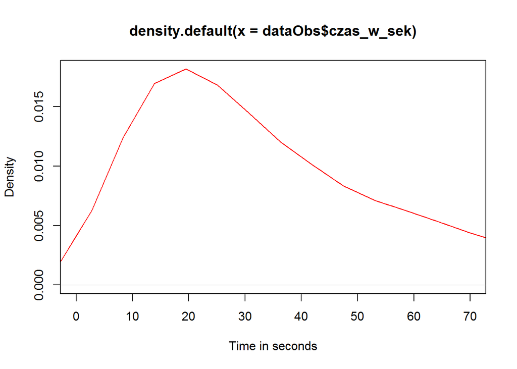

```r
plot(density(dataObs$czas_w_sek), xlim=c(0,70), col="red", xlab="Time in seconds")
```

# Histogram

Histogram were used to notice if grades can be considered as outliner variables

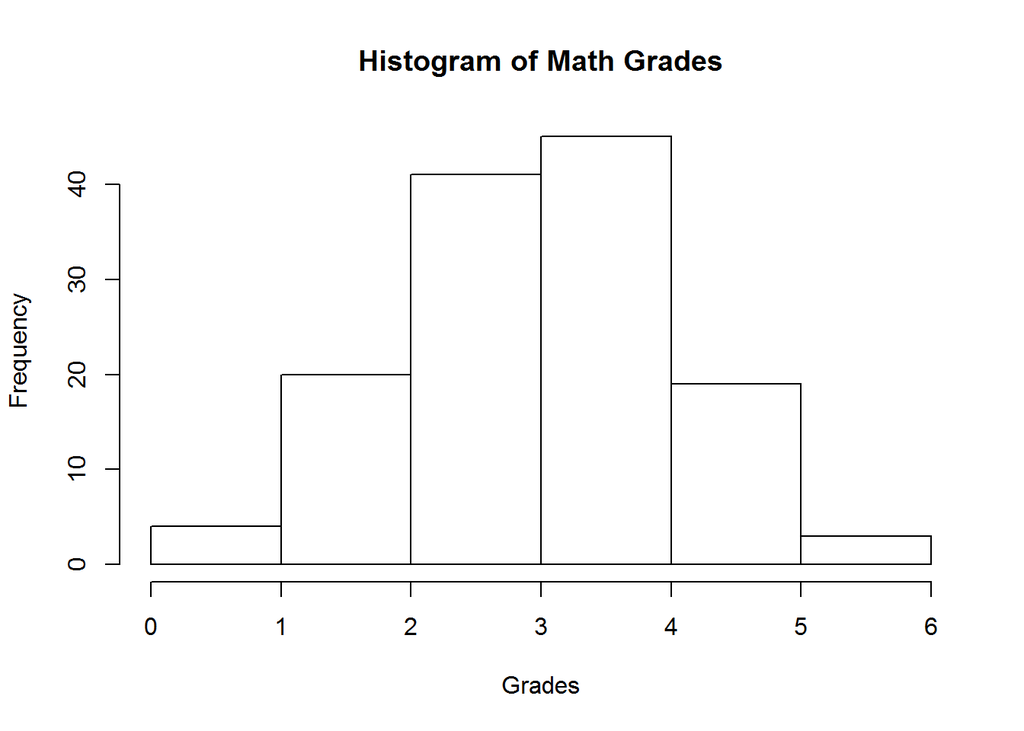

```r
attach(dataObs)
attach(dataForm)

grades <- seq(0, 6, 1)

hist(oceM, breaks=grades, xlab = "Grades", ylab = "Frequency", main = "Histogram of Math Grades", cex=0.1)
```

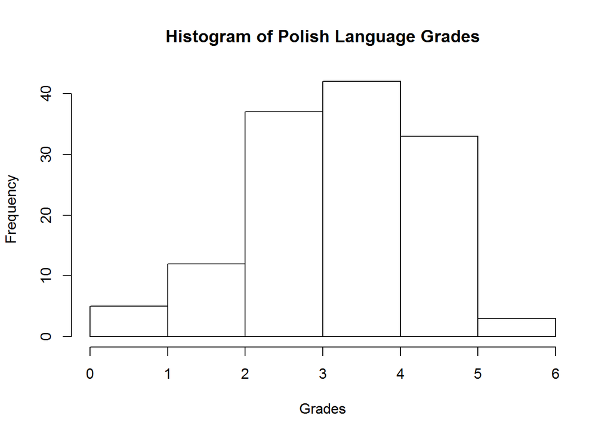

```r
hist(oceJP, breaks=grades, xlab = "Grades", ylab = "Frequency", main = "Histogram of Polish Language Grades", cex=0.1)
```

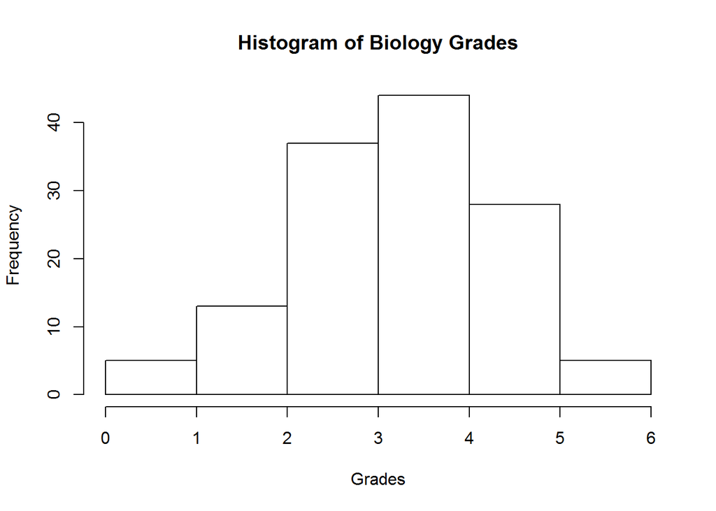

```r
hist(oceP, breaks=grades, xlab = "Grades", ylab = "Frequency", main = "Histogram of Biology Grades", cex=0.1)
```

# Boxplots

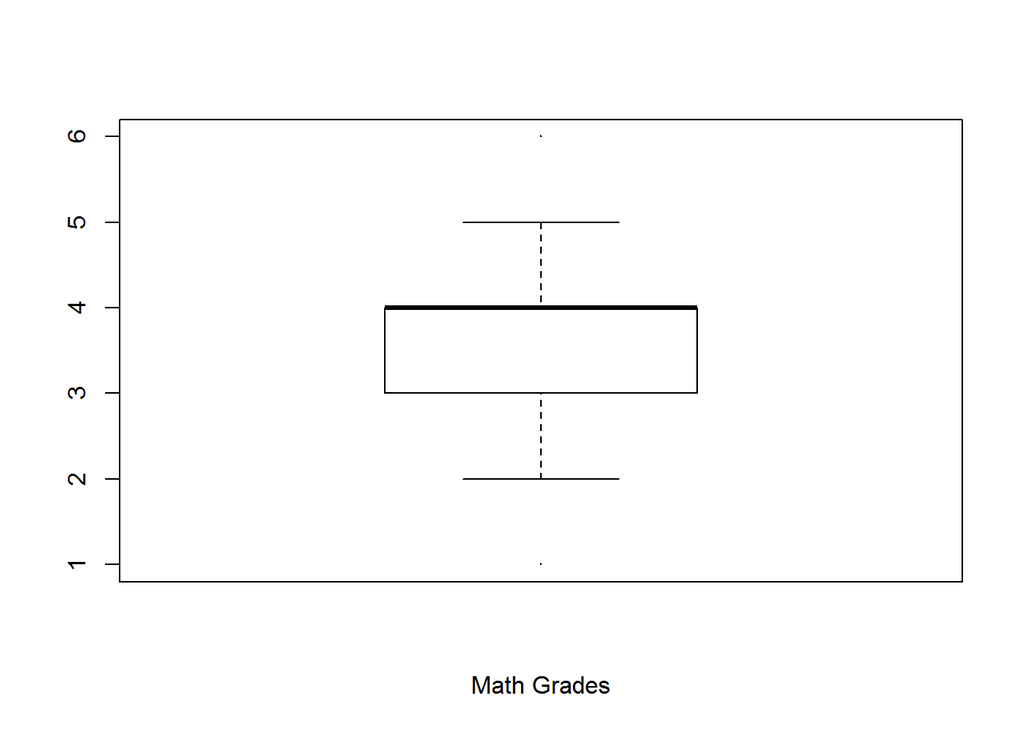

```r
boxplot(oceM, bty="n",xlab = "Math Grades", cex=0.1)
```

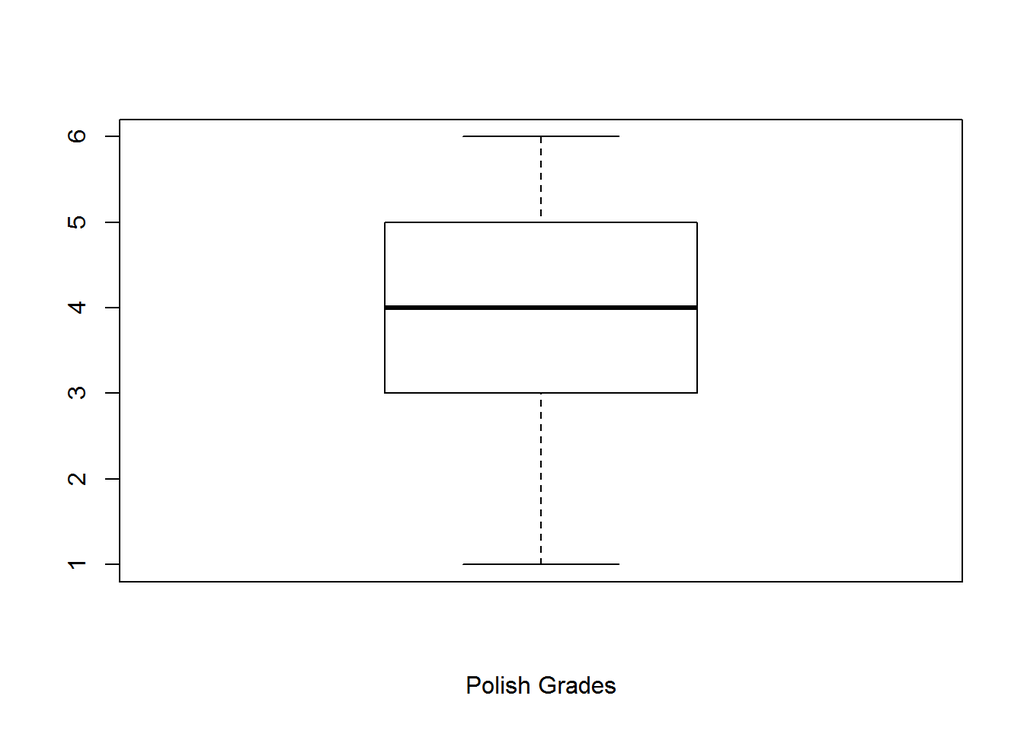

```r
boxplot(oceJP, bty="n",xlab = "Polish Grades", cex=0.1)
```

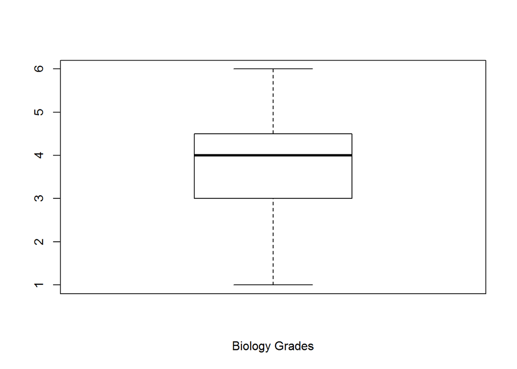

```r
boxplot(oceP, bty="n",xlab = "Biology Grades", cex=0.1)
```

[output not shown]

# Scatterplots

Scatterplots are used to visualize data.

Categories of exhibits:

1- breaks 2 - exhibits 3 - other atractions

Categories of behavior:

1 - Observation 2 - Touching 3 - Using 4 - Experiments

Categories of Gender:

1 - Girls 2 - Boys

Parents studies/work: 1 - Yes 2 - No 3 - I dont know

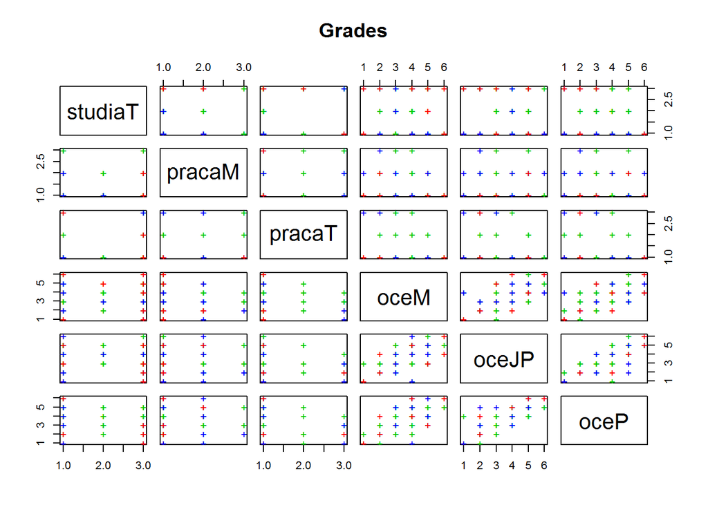

```r
 pairs(dataForm[,10:15], main = "Grades", pch = "+", col = c("red", "green3",  "blue"))
```

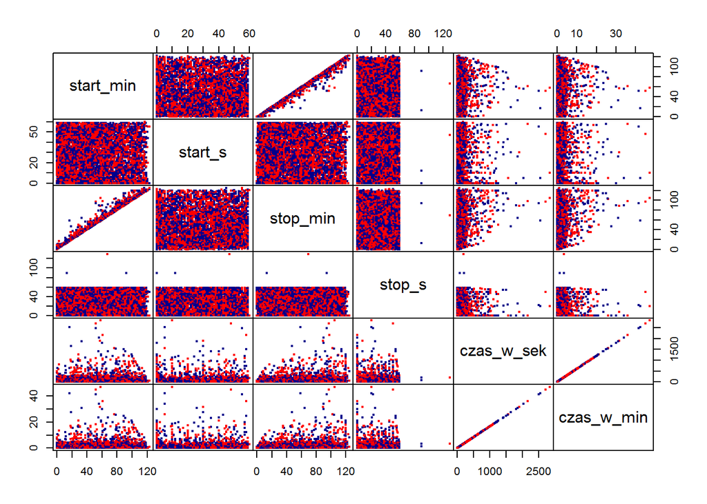

```r
pairs(dataObs[,4:9], gap=0, pch=19, cex=0.4, col=c("darkblue","red"))
```

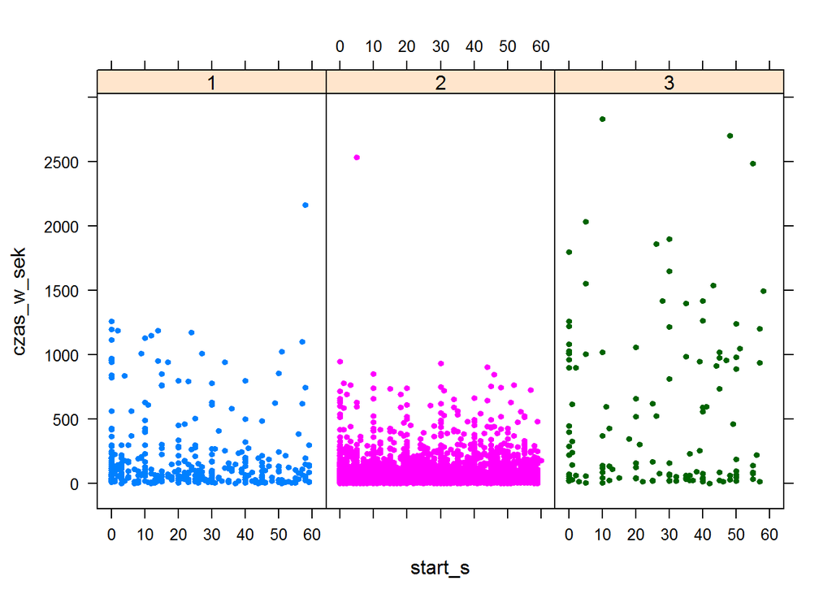

```r
xyplot(czas_w_sek ~ start_s | kategorie, dataObs, groups = dataObs$kategorie, pch= 20)
```

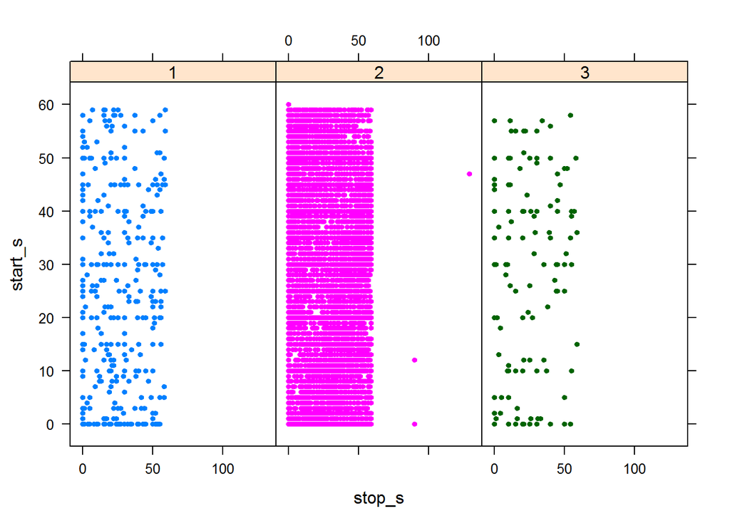

```r
xyplot(start_s ~ stop_s | kategorie, dataObs, groups = dataObs$kategorie, pch= 20)
```

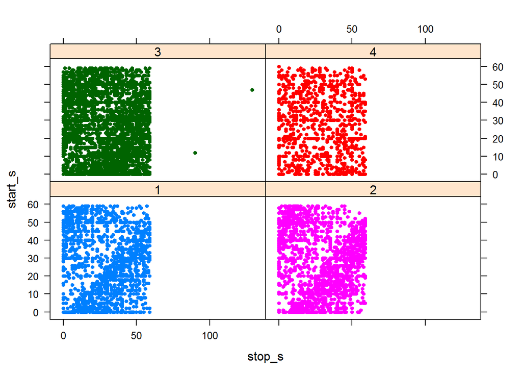

```r
xyplot(start_s ~ stop_s | zach, dataObs, groups = dataObs$zach, pch= 20)
```

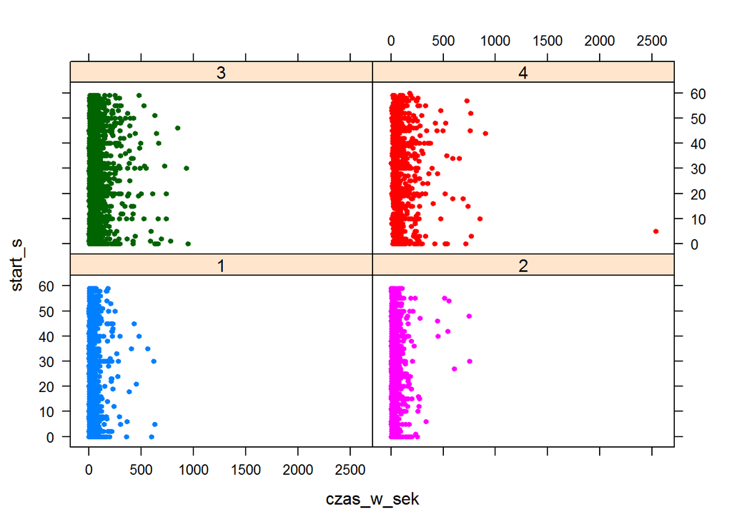

```r
xyplot(start_s ~ czas_w_sek | zach, dataObs, groups = dataObs$zach, pch= 20)
```

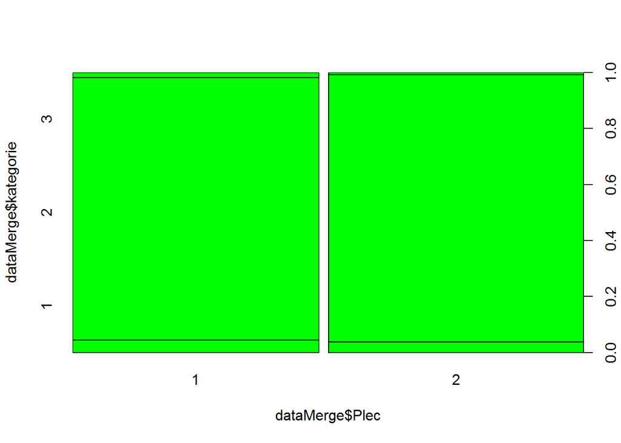

```r
dataMerge$Plec<-as.factor(dataMerge$Plec)
dataMerge$kategorie<-as.factor(dataMerge$kategorie)
dataMerge$oceP<-as.factor(dataMerge$oceP)
dataForm$Plec<-as.factor(dataForm$Plec)
#dataForm$OceM<-as.factor(dataForm$OceM)
dataForm$oceJP<-as.factor(dataForm$oceJP)
#dataForm$OceP<-as.factor(dataForm$OceP)

spineplot(dataMerge$Plec,dataMerge$kategorie, col="green")
```

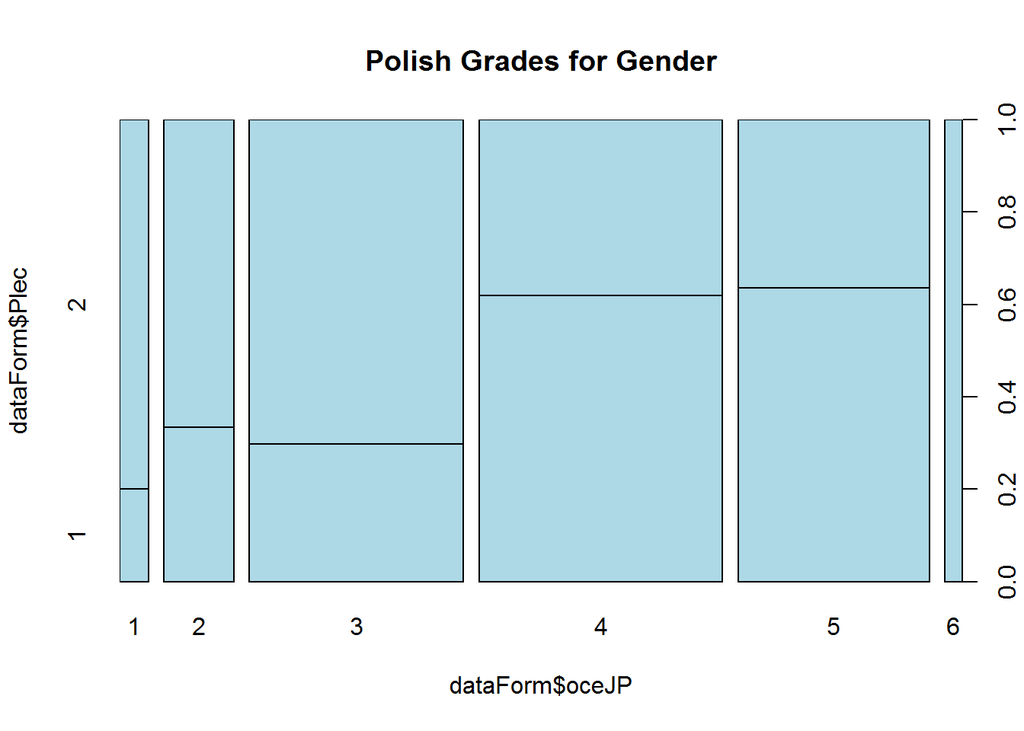

```r
spineplot(dataForm$Plec ~ dataForm$oceJP , col="lightblue", main="Polish Grades for Gender")
```

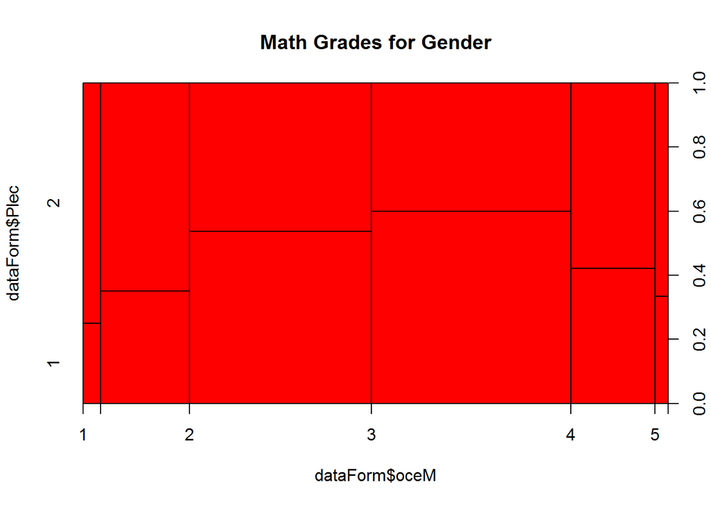

```r
spineplot(dataForm$Plec ~ dataForm$oceM , col="red", main="Math Grades for Gender")
```

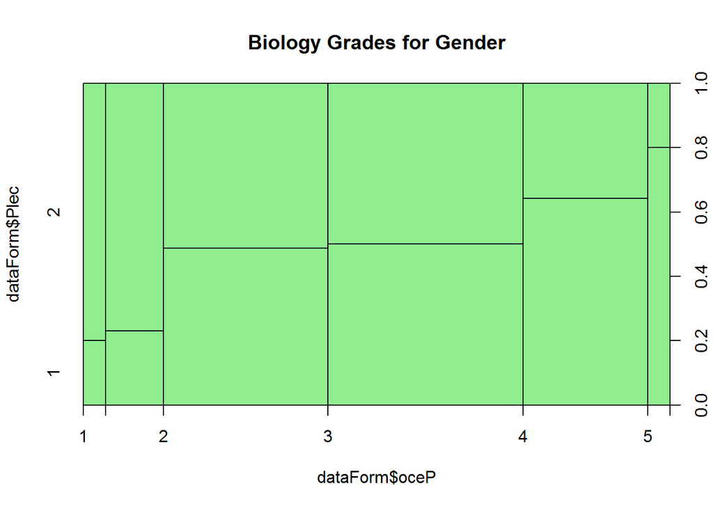

```r
spineplot(dataForm$Plec ~ dataForm$oceP , col="lightgreen", main="Biology Grades for Gender")
```

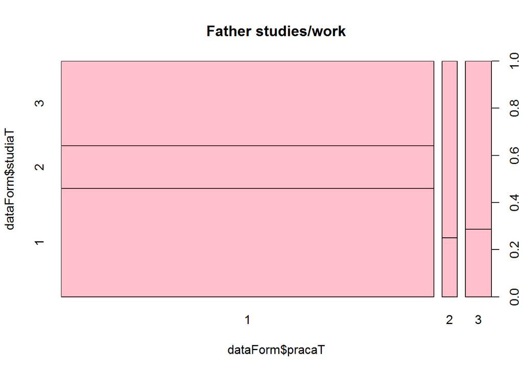

```r
spineplot(dataForm$studiaT ~ dataForm$pracaT , col="pink", main="Father studies/work")
```

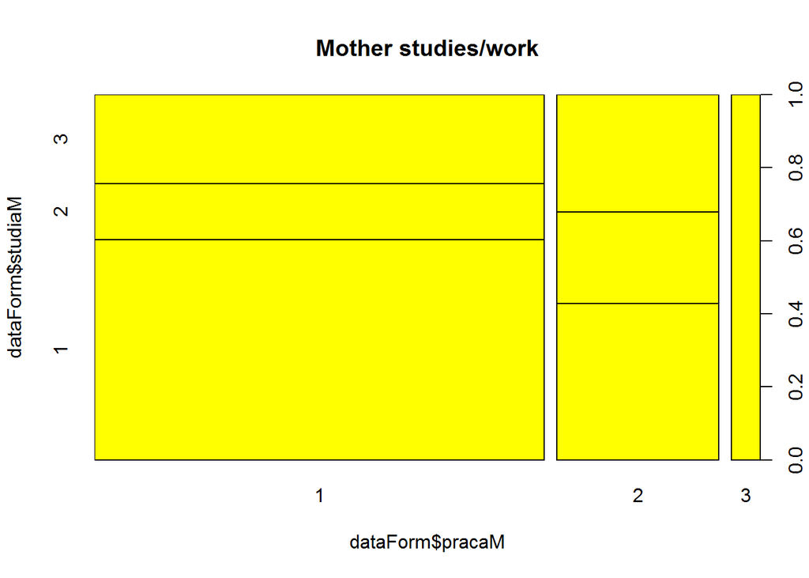

```r
spineplot(dataForm$studiaM ~ dataForm$pracaM , col="yellow", main="Mother studies/work")
```

```r
#xyplot(start_s ~ czas_w_sek | Plec, data, groups = dataMerge$Plec, pch= 20)

#xyplot(start_s ~ stop_s | Plec, data, groups = dataMerge$Plec, pch= 20)
```

# XY plot

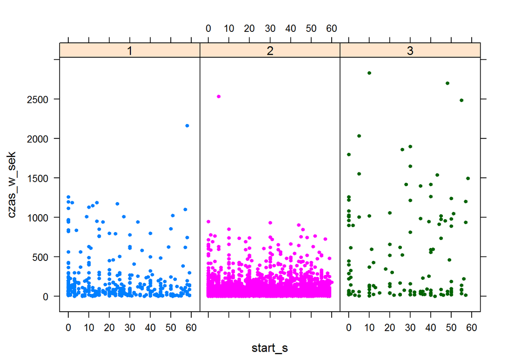

```r
xyplot(czas_w_sek ~ start_s | kategorie, dataObs, groups = dataObs$kategorie, pch= 20)
```

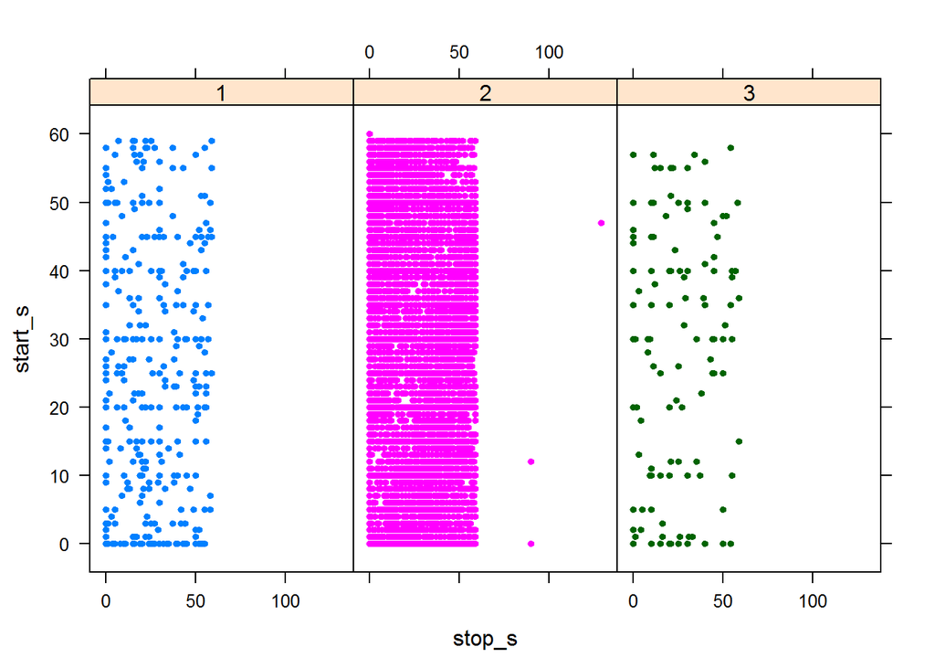

```r
xyplot(start_s ~ stop_s | kategorie, dataObs, groups = dataObs$kategorie, pch= 20)
```

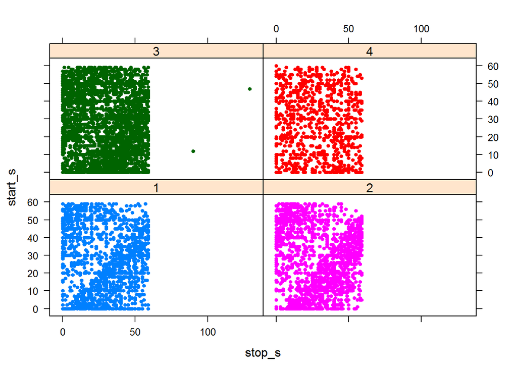

```r
xyplot(start_s ~ stop_s | zach, dataObs, groups = dataObs$zach, pch= 20)
```

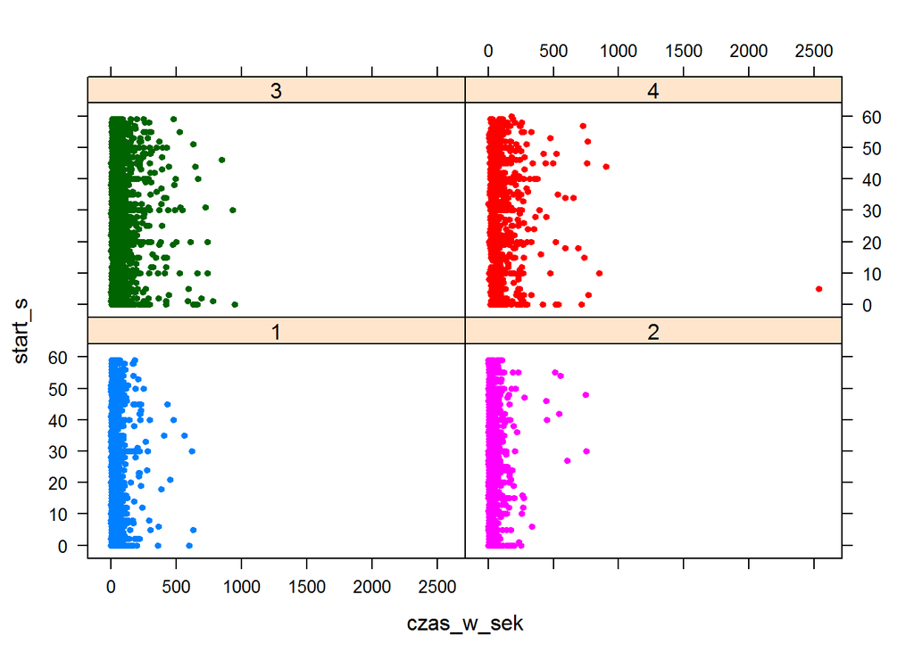

```r
xyplot(start_s ~ czas_w_sek | zach, dataObs, groups = dataObs$zach, pch= 20)
```